# index

Lin Boding

2023-06-16

#加载包

```r
library(tidyverse)
library(car)
library(multcomp)
library(multcompView)
library(rstatix)
library(faraway) #数据来源
library(ggsci) #用于配色
```

# 探索数据

```r
?rats #了解数据
head(rats) #了解其结构
```

```
##   time poison treat
## 1 0.31      I     A
## 2 0.82      I     B
## 3 0.43      I     C
## 4 0.45      I     D
## 5 0.45      I     A
## 6 1.10      I     B
```

```r
table(rats$poison, rats$treat) #看实验设计是否均衡
```

```
##
##       A B C D
##   I   4 4 4 4
##   II  4 4 4 4
##   III 4 4 4 4
```

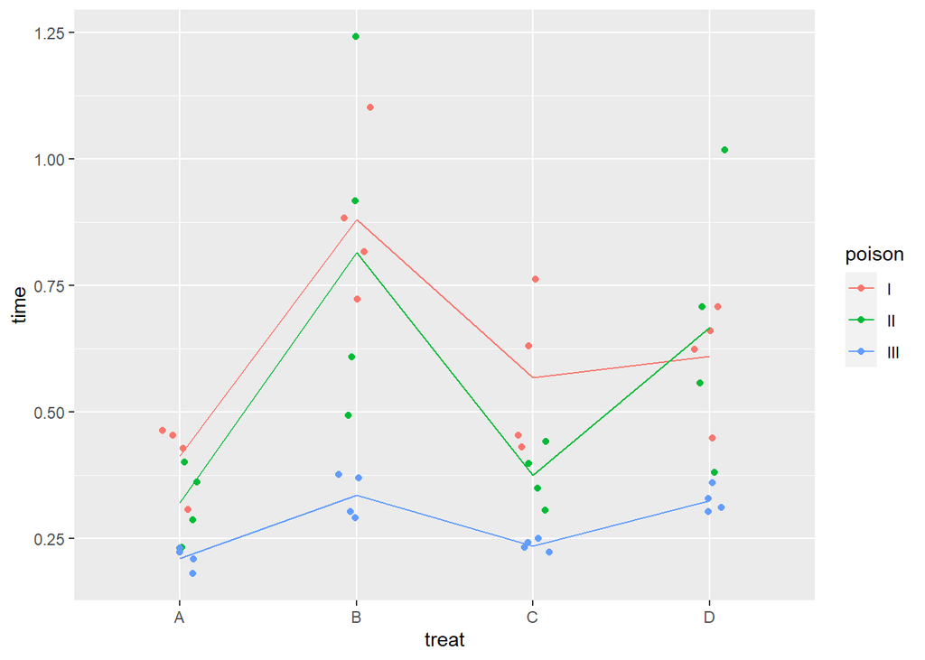

```r
ggplot(rats, aes(treat, time, color = poison)) +
  geom_jitter(width = 0.1) +
  stat_summary(geom = "line", fun = mean, aes(group = poison)) #大体了解一下数据
```

通过初步分析可以发现，实验设计是均衡的，可以用最常规的ANOVA，初步可视化发现poison和treat的交互作用是不太重要的。 提出问题： * 小鼠存活时间是否受毒药类型影响 * 小鼠存活时间是否是处理类型影响 * 两个因素在影响小鼠存活时有无交互作用

# Two-way ANOVA of rats

## 检验poison和treat的交互效应

```r
mod.1 <- aov(time ~ poison * treat, data = rats)
summary(mod.1)
```

```
##              Df Sum Sq Mean Sq F value   Pr(>F)
## poison        2 1.0330  0.5165  23.222 3.33e-07 ***
## treat         3 0.9212  0.3071  13.806 3.78e-06 ***
## poison:treat  6 0.2501  0.0417   1.874    0.112
## Residuals    36 0.8007  0.0222
## ---
## Signif. codes:  0 '***' 0.001 '**' 0.01 '*' 0.05 '.' 0.1 ' ' 1
```

```r
rstatix::eta_squared(mod.1)
```

```
##       poison        treat poison:treat
##   0.34375526   0.30654953   0.08323818
```

解读： * poison:treat：两者在影响time时交互作用不显著（p=0.112） * 交互作用比两个主效应小很多 * 不用保留交互作用，直接分析主效应

## 没有交互作用的双因素方差分析

```r
mod.1a <- aov(time ~ poison + treat, data = rats)
summary(mod.1a)
```

```
##             Df Sum Sq Mean Sq F value  Pr(>F)
## poison       2 1.0330  0.5165   20.64 5.7e-07 ***
## treat        3 0.9212  0.3071   12.27 6.7e-06 ***
## Residuals   42 1.0509  0.0250
## ---
## Signif. codes:  0 '***' 0.001 '**' 0.01 '*' 0.05 '.' 0.1 ' ' 1
```

```r
post.1 <- TukeyHSD(mod.1a, which = "poison") #单独事后比较，分析poison的主效应
post.1
```

```
##   Tukey multiple comparisons of means
##     95% family-wise confidence level
##
## Fit: aov(formula = time ~ poison + treat, data = rats)
##
## $poison
##             diff        lwr        upr     p adj
## II-I   -0.073125 -0.2089936  0.0627436 0.3989657
## III-I  -0.341250 -0.4771186 -0.2053814 0.0000008
## III-II -0.268125 -0.4039936 -0.1322564 0.0000606
```

```r
p.value_p <- post.1$poison[, 4]
let_p <- multcompLetters(p.value_p) # 事后比较结果转化为字母表达
let_p
```

```
##  II III   I
## "a" "b" "a"
```

```r
post.2 <- TukeyHSD(mod.1a, which = "treat") #单独事后比较，分析treat的主效应
post.2
```

```
##   Tukey multiple comparisons of means
##     95% family-wise confidence level
##
## Fit: aov(formula = time ~ poison + treat, data = rats)
##
## $treat
##            diff         lwr         upr     p adj
## B-A  0.36250000  0.18976135  0.53523865 0.0000083
## C-A  0.07833333 -0.09440532  0.25107198 0.6221729
## D-A  0.22000000  0.04726135  0.39273865 0.0076661
## C-B -0.28416667 -0.45690532 -0.11142802 0.0004090
## D-B -0.14250000 -0.31523865  0.03023865 0.1380432
## D-C  0.14166667 -0.03107198  0.31440532 0.1416151
```

```r
p.value_t <- post.2$treat[, 4]
let_t <- multcompLetters(p.value_t) # 事后比较结果转化为字母表达
let_t
```

```
##    B    C    D    A
##  "a" "bc" "ab"  "c"
```

# 结果可视化

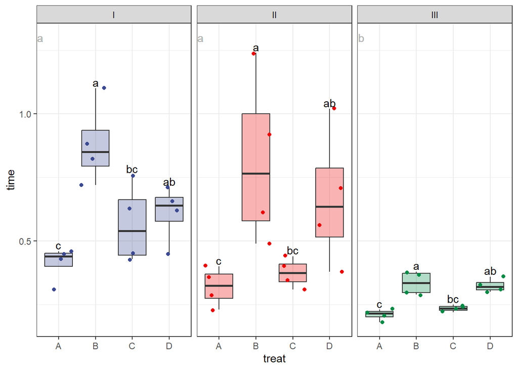

```r
d_pvalue_t <- data.frame(treat=c("B","C","D","A"),
                       label_t=as.vector(let_t$Letters))
d_pvalue_p <- data.frame(poison=c("II", "III", "I"),
                         label_p=as.vector(let_p$Letters))

d_label <- rats |>
  group_by(treat, poison) |>
  summarise(y_pos=max(time)) |>
  left_join(d_pvalue_t, by="treat") |>
  left_join(d_pvalue_p, by="poison") # 将字母标注和原数据表格合并

ggplot(rats, aes(treat,time)) +
  scale_fill_aaas()+
  scale_color_aaas() +
  geom_boxplot(outlier.alpha = 0, aes(fill = poison), alpha = 0.3) +
  geom_jitter(aes(color = poison)) +
  geom_text(data = d_label, aes(x = treat, y = y_pos+0.025, label = label_t), color = "black") +
  geom_text(data = d_label, aes(x = 0.5, y = 1.3, label = label_p), color = "grey70") +
  theme_bw() +
  theme(legend.position = "none") +
  facet_wrap(~poison)
```

结果：这副图是不同毒药和不同处理下小鼠的存活时间，图中左上角灰色字母表示以三种毒药类型为主效应是否有显著区别，字母相同不显著，不相同显著；途中箱线图上方字母表示以四种处理为主效应是否有显著区别。 回答问题：两种主效应能显著影响小鼠的存活时间，毒药的效果I和II大于III，处理的效果B>D>C>A，交互作用不显著。